# Exp 1 analysis

Kenny Smith

18/12/2023

This builds from the analysis for Bowerman & Smith (2022) in CogSci proceedings.

# Data loading etc

Read in anonymised data - clean-up has been done during the anonymisation process, so only participants with valid data who did not take notes etc is included here.

```r
data <- read.csv("data/exp1_data_anonymised.csv")
```

## Number of pairs per condition

Quick look at number of remaining pairs per condition.

```r
plyr::ddply(data,~condition,plyr::summarise,Current_N=length(unique(pair_id)))
```

```
##             condition Current_N
## 1  fixed_associations        54
## 2 random_associations        53
```

# Plots and stats

## Plots and stats of success vs block

Score is recorded only on matcher trials so can discard the director trials for the score analyses.

```r
matcher_data <- subset(data,exp_trial_type=='matcher')
```

Score=1 on trials where the matcher succesfully selected the target, score=0 otherwise.

Plotting by-pair average score (i.e. proportion of score=1 trials) per block. I want a dotplot so we can individual pairs.

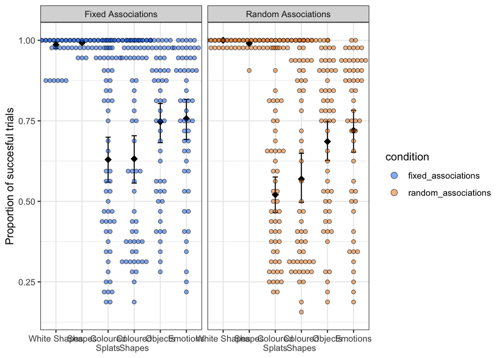

Same plot just showing block 2 onwards, since all the points clustered at 1 in block 1 makes it a bit hard to see what’s happening in block 2!

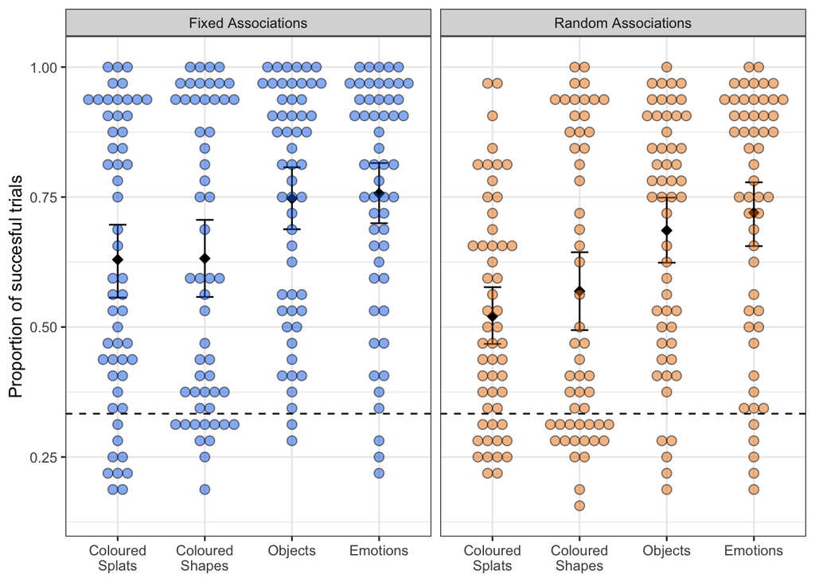

Given the very high performance, it should be sufficient to report that mean in blocks 0 (white shapes) and 1 (trivial shapes) is high.

Block 0.

```r
mean(subset(pair_means_per_block,block_n==0)$score)
```

```
## [1] 0.9929907
```

```r
stem(subset(pair_means_per_block,block_n==0)$score)
```

```
##
##   The decimal point is 2 digit(s) to the left of the |
##
##    87 | 555555
##    88 |
##    89 |
##    90 |
##    91 |
##    92 |
##    93 |
##    94 |
##    95 |
##    96 |
##    97 |
##    98 |
##    99 |
##   100 | 00000000000000000000000000000000000000000000000000000000000000000000+21
```

Block 1.

```r
mean(subset(pair_means_per_block,block_n==1)$score)
```

```
## [1] 0.9916764
```

```r
stem(subset(pair_means_per_block,block_n==1)$score)
```

```
##
##   The decimal point is 2 digit(s) to the left of the |
##
##    90 | 6
##    91 |
##    91 |
##    92 |
##    92 |
##    93 |
##    93 |
##    94 |
##    94 |
##    95 | 333
##    95 |
##    96 |
##    96 | 999999
##    97 |
##    97 |
##    98 | 444444444444444444444444444444
##    98 |
##    99 |
##    99 |
##   100 | 0000000000000000000000000000000000000000000000000000000000000000000
```

Key stat - are there effects of condition on score? We care about block 2 (splats) onwards. We predict particularly an effect at block 2 (the splats block), so want to get that straightforwardly from our analysis. We’d also like to know if the scores change over blocks, and whether this differ between conditions.

```r
matcher_data_block2on <- subset(matcher_data,block_n>=2)
matcher_data_block2on$block_n_factor <- as.factor(matcher_data_block2on$block_n)
matcher_data_block2on$condition_factor <- as.factor(matcher_data_block2on$condition)
contrasts(matcher_data_block2on$condition_factor) <- contr.sum(2)
```

Basic model with block dummy-coded - shows that the conditions differ at block 2, and that all subsequent blocks have higher accuracy than block 2; no condition * block interaction, so basically the random_association guys start lower and (according to this) stay lower, although you can see from the coefficients for later blocks that the difference is narrowing.

```r
#fails to converge with default settings, so using bobyqa and more iterations
score_model <- glmer(score~block_n_factor*condition_factor + (1 + block_n_factor | pair_id),data=matcher_data_block2on,family='binomial',control=glmerControl(optimizer="bobyqa",optCtrl=list(maxfun=100000)))

summary(score_model)
```

```
## Generalized linear mixed model fit by maximum likelihood (Laplace
##   Approximation) [glmerMod]
##  Family: binomial  ( logit )
## Formula: score ~ block_n_factor * condition_factor + (1 + block_n_factor |
##     pair_id)
##    Data: matcher_data_block2on
## Control: glmerControl(optimizer = "bobyqa", optCtrl = list(maxfun = 1e+05))
##
##      AIC      BIC   logLik deviance df.resid
##  14237.0  14372.5  -7100.5  14201.0    13678
##
## Scaled residuals:
##     Min      1Q  Median      3Q     Max
## -5.6373 -0.6877  0.2873  0.5666  1.8197
##
## Random effects:
##  Groups  Name            Variance Std.Dev. Corr
##  pair_id (Intercept)     1.4592   1.2080
##          block_n_factor3 0.4241   0.6513    0.38
##          block_n_factor4 0.8836   0.9400   -0.24  0.12
##          block_n_factor5 1.7270   1.3142   -0.37  0.00  0.66
## Number of obs: 13696, groups:  pair_id, 107
##
## Fixed effects:
##                                   Estimate Std. Error z value Pr(>|z|)
## (Intercept)                        0.46303    0.12422   3.727 0.000193 ***
## block_n_factor3                    0.26192    0.09040   2.897 0.003766 **
## block_n_factor4                    0.81724    0.11318   7.221 5.17e-13 ***
## block_n_factor5                    0.98031    0.14508   6.757 1.41e-11 ***
## condition_factor1                  0.32449    0.12396   2.618 0.008854 **
## block_n_factor3:condition_factor1 -0.08431    0.08775  -0.961 0.336649
## block_n_factor4:condition_factor1 -0.07882    0.11109  -0.710 0.477991
## block_n_factor5:condition_factor1 -0.18903    0.14339  -1.318 0.187405
## ---
## Signif. codes:  0 '***' 0.001 '**' 0.01 '*' 0.05 '.' 0.1 ' ' 1
##
## Correlation of Fixed Effects:
##             (Intr) blc__3 blc__4 blc__5 cndt_1 b__3:_ b__4:_
## blck_n_fct3  0.096
## blck_n_fct4 -0.308  0.240
## blck_n_fct5 -0.405  0.133  0.576
## cndtn_fctr1  0.010 -0.024 -0.018 -0.013
## blck_n_3:_1 -0.023  0.066  0.022  0.018  0.109
## blck_n_4:_1 -0.018  0.024  0.050  0.014 -0.308  0.242
## blck_n_5:_1 -0.013  0.019  0.015  0.018 -0.407  0.131  0.592
```

Same analysis with successive difference coding for block - this will show us block-to-block changes. NB the main effect of condition here is over all blocks (because of the way successive difference coding works), and the levels of the block factor are:

“2-1” is block 2 to block 3 “3-2” is block 3 to block 4 “4-3” is block 4 to block 5

This suggests that there is significant improvement from block 2 to block 3, and from 3 to 4, but no interaction with condition. Note that the main effect of condition here is over all blocks, because of the way successive difference coding for block works.

```r
matcher_data_block2on$block_n_factor_sdif <- matcher_data_block2on$block_n_factor
contrasts(matcher_data_block2on$block_n_factor_sdif) <- MASS::contr.sdif(4)
score_model_sdif <- glmer(score~block_n_factor_sdif*condition_factor + (1 + block_n_factor_sdif | pair_id),data=matcher_data_block2on,family='binomial',control=glmerControl(optimizer="bobyqa",optCtrl=list(maxfun=100000)))

summary(score_model_sdif)
```

```
## Generalized linear mixed model fit by maximum likelihood (Laplace
##   Approximation) [glmerMod]
##  Family: binomial  ( logit )
## Formula:
## score ~ block_n_factor_sdif * condition_factor + (1 + block_n_factor_sdif |
##     pair_id)
##    Data: matcher_data_block2on
## Control: glmerControl(optimizer = "bobyqa", optCtrl = list(maxfun = 1e+05))
##
##      AIC      BIC   logLik deviance df.resid
##  14237.0  14372.5  -7100.5  14201.0    13678
##
## Scaled residuals:
##     Min      1Q  Median      3Q     Max
## -5.6373 -0.6877  0.2873  0.5666  1.8197
##
## Random effects:
##  Groups  Name                   Variance Std.Dev. Corr
##  pair_id (Intercept)            1.4813   1.2171
##          block_n_factor_sdif2-1 0.4241   0.6512    0.54
##          block_n_factor_sdif3-2 1.1557   1.0750   -0.19 -0.50
##          block_n_factor_sdif4-3 0.9782   0.9890   -0.10 -0.12  0.01
## Number of obs: 13696, groups:  pair_id, 107
##
## Fixed effects:
##                                           Estimate Std. Error z value Pr(>|z|)
## (Intercept)                               0.977886   0.120408   8.121 4.61e-16
## block_n_factor_sdif2-1                    0.261898   0.090418   2.897  0.00377
## block_n_factor_sdif3-2                    0.555333   0.126768   4.381 1.18e-05
## block_n_factor_sdif4-3                    0.163074   0.122231   1.334  0.18216
## condition_factor1                         0.236449   0.120206   1.967  0.04918
## block_n_factor_sdif2-1:condition_factor1 -0.084317   0.087759  -0.961  0.33666
## block_n_factor_sdif3-2:condition_factor1  0.005491   0.123791   0.044  0.96462
## block_n_factor_sdif4-3:condition_factor1 -0.110205   0.118468  -0.930  0.35224
##
## (Intercept)                              ***
## block_n_factor_sdif2-1                   **
## block_n_factor_sdif3-2                   ***
## block_n_factor_sdif4-3
## condition_factor1                        *
## block_n_factor_sdif2-1:condition_factor1
## block_n_factor_sdif3-2:condition_factor1
## block_n_factor_sdif4-3:condition_factor1
## ---
## Signif. codes:  0 '***' 0.001 '**' 0.01 '*' 0.05 '.' 0.1 ' ' 1
##
## Correlation of Fixed Effects:
##             (Intr) bl___2-1 bl___3-2 bl___4-3 cndt_1 b___2-1: b___3-2:
## blck_n__2-1  0.383
## blck_n__3-2 -0.152 -0.499
## blck_n__4-3 -0.074 -0.064   -0.170
## cndtn_fctr1 -0.002 -0.001    0.003   -0.003
## bl___2-1:_1  0.000  0.066   -0.027    0.000    0.390
## bl___3-2:_1  0.002 -0.026    0.044   -0.026   -0.156 -0.491
## bl___4-3:_1 -0.003  0.000   -0.026    0.036   -0.078 -0.069   -0.149
```

## Plots and stats of success over block and trial per block

Timecourses are useful, but to do these sensibly we need to convert trial_n (which is overall trial number) to something more meaningful, specifically trial number *in a given block*. Since there is some variability in trial number depending on what participants did on the warm-up trials, need to work out per-pair the lowest trial number per block and then subtract that from the raw trial numbers.

```r
adjusted_trial_n_df <- NULL
for (p in unique(matcher_data$pair_id)) {
  this_p_data <- subset(matcher_data,pair_id==p)
  for (b in unique(this_p_data$block_n)) {
    this_b_data <- subset(this_p_data,block_n==b)
    first_trial_n <- min(this_b_data$trial_n)
    this_df <- data.frame("pair_id"=p,
               "block_n"=b,
               "trial_n"=this_b_data$trial_n,
               "trial_n_in_block"=this_b_data$trial_n-first_trial_n)
    adjusted_trial_n_df <- rbind(adjusted_trial_n_df,this_df)
  }
}

#merge to get the adjusted trial numbers.
matcher_data <- merge(matcher_data,adjusted_trial_n_df,by=c("pair_id","block_n","trial_n"))
```

Plot the timecourses - note I am plotting the mean of all pairs here (since the individual pairs either succeed or fail on any given trial, so those are not informative) plus bootstrepped CIs, and focussing only on blocks 2 (splats) onwards.

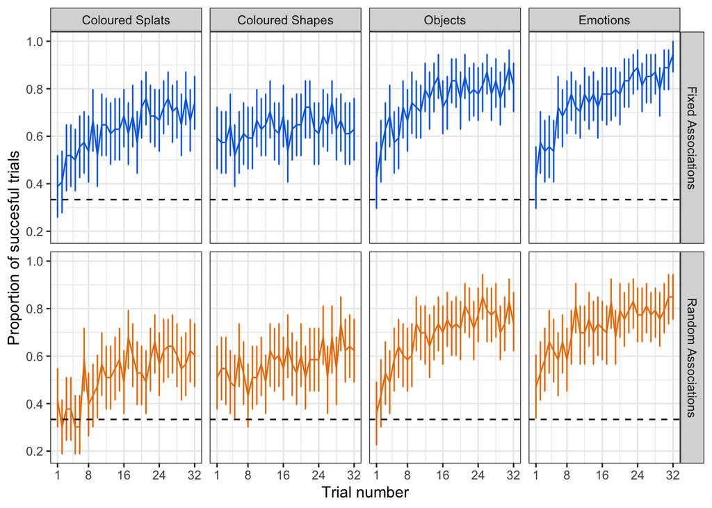

The question with the stats here is: is there a 3-way interaction between condition, block and trial number? Easiest way to find out is to compare models and do a likelihood ratio test (to avoid trying to work out the right kind of contrasts for block which would allow me to answer this question!), which suggests a marginal interaction.

```r
#need to re-run these since we have added the per-block trial numbers to matcher_data
matcher_data_block2on <- subset(matcher_data,block_n>=2)
matcher_data_block2on$block_n_factor <- as.factor(matcher_data_block2on$block_n)
matcher_data_block2on$condition_factor <- as.factor(matcher_data_block2on$condition)
contrasts(matcher_data_block2on$condition_factor) <- contr.sum(2)

#also need to scale and centre trial_n to ease convergence issues - setting so 0=-1, 31=1
matcher_data_block2on$trial_n_in_block_scaled_centred <- (matcher_data_block2on$trial_n_in_block-15.5)/15.5

score_model_trialn <- glmer(score~block_n_factor*condition_factor*trial_n_in_block_scaled_centred + (1 + block_n_factor * trial_n_in_block_scaled_centred | pair_id),data=matcher_data_block2on,family='binomial',control=glmerControl(optimizer="bobyqa",optCtrl=list(maxfun=100000)))
```

```
## boundary (singular) fit: see help('isSingular')
```

```r
score_model_trialn_minus <- glmer(score~block_n_factor*condition_factor*trial_n_in_block_scaled_centred -block_n_factor:condition_factor:trial_n_in_block_scaled_centred + (1 + block_n_factor * trial_n_in_block_scaled_centred | pair_id),data=matcher_data_block2on,family='binomial',control=glmerControl(optimizer="bobyqa",optCtrl=list(maxfun=100000)))
```

```
## boundary (singular) fit: see help('isSingular')
```

```r
anova(score_model_trialn,score_model_trialn_minus)
```

```
## Data: matcher_data_block2on
## Models:
## score_model_trialn_minus: score ~ block_n_factor * condition_factor * trial_n_in_block_scaled_centred - block_n_factor:condition_factor:trial_n_in_block_scaled_centred + (1 + block_n_factor * trial_n_in_block_scaled_centred | pair_id)
## score_model_trialn: score ~ block_n_factor * condition_factor * trial_n_in_block_scaled_centred + (1 + block_n_factor * trial_n_in_block_scaled_centred | pair_id)
##                          npar   AIC   BIC  logLik deviance  Chisq Df Pr(>Chisq)
## score_model_trialn_minus   49 13345 13714 -6623.7    13247
## score_model_trialn         52 13345 13736 -6620.4    13241 6.6595  3    0.08358
##
## score_model_trialn_minus
## score_model_trialn       .
## ---
## Signif. codes:  0 '***' 0.001 '**' 0.01 '*' 0.05 '.' 0.1 ' ' 1
```

Post-hocs: are there condition x trial number interactions at each block? These suggest marginal interactions at block 2 (which is clear in the graph) and block 5 (the fixed association people go up faster and reach a slightly higher level).

Block 2 (coloured splats):

```r
score_model_trialn_block2 <- glmer(score~condition_factor*trial_n_in_block_scaled_centred + (1 + trial_n_in_block_scaled_centred | pair_id),data=subset(matcher_data_block2on,block_n==2),family='binomial',control=glmerControl(optimizer="bobyqa",optCtrl=list(maxfun=100000)))
summary(score_model_trialn_block2)
```

```
## Generalized linear mixed model fit by maximum likelihood (Laplace
##   Approximation) [glmerMod]
##  Family: binomial  ( logit )
## Formula: score ~ condition_factor * trial_n_in_block_scaled_centred +
##     (1 + trial_n_in_block_scaled_centred | pair_id)
##    Data: subset(matcher_data_block2on, block_n == 2)
## Control: glmerControl(optimizer = "bobyqa", optCtrl = list(maxfun = 1e+05))
##
##      AIC      BIC   logLik deviance df.resid
##   3794.5   3837.4  -1890.2   3780.5     3417
##
## Scaled residuals:
##     Min      1Q  Median      3Q     Max
## -7.6772 -0.7147  0.1359  0.6798  2.0327
##
## Random effects:
##  Groups  Name                            Variance Std.Dev. Corr
##  pair_id (Intercept)                     2.721    1.65
##          trial_n_in_block_scaled_centred 1.716    1.31     0.94
## Number of obs: 3424, groups:  pair_id, 107
##
## Fixed effects:
##                                                   Estimate Std. Error z value
## (Intercept)                                         0.7578     0.1720   4.406
## condition_factor1                                   0.4627     0.1694   2.732
## trial_n_in_block_scaled_centred                     1.2178     0.1595   7.636
## condition_factor1:trial_n_in_block_scaled_centred   0.2949     0.1536   1.920
##                                                   Pr(>|z|)
## (Intercept)                                       1.05e-05 ***
## condition_factor1                                   0.0063 **
## trial_n_in_block_scaled_centred                   2.25e-14 ***
## condition_factor1:trial_n_in_block_scaled_centred   0.0549 .
## ---
## Signif. codes:  0 '***' 0.001 '**' 0.01 '*' 0.05 '.' 0.1 ' ' 1
##
## Correlation of Fixed Effects:
##             (Intr) cndt_1 t_____
## cndtn_fctr1 0.045
## trl_n_n_b__ 0.830  0.066
## cnd_1:_____ 0.068  0.826  0.107
```

Block 3 (coloured shapes):

```r
score_model_trialn_block3 <- glmer(score~condition_factor*trial_n_in_block_scaled_centred + (1 + trial_n_in_block_scaled_centred | pair_id),data=subset(matcher_data_block2on,block_n==3),family='binomial',control=glmerControl(optimizer="bobyqa",optCtrl=list(maxfun=100000)))
summary(score_model_trialn_block3)
```

```
## Generalized linear mixed model fit by maximum likelihood (Laplace
##   Approximation) [glmerMod]
##  Family: binomial  ( logit )
## Formula: score ~ condition_factor * trial_n_in_block_scaled_centred +
##     (1 + trial_n_in_block_scaled_centred | pair_id)
##    Data: subset(matcher_data_block2on, block_n == 3)
## Control: glmerControl(optimizer = "bobyqa", optCtrl = list(maxfun = 1e+05))
##
##      AIC      BIC   logLik deviance df.resid
##   3649.6   3692.5  -1817.8   3635.6     3417
##
## Scaled residuals:
##     Min      1Q  Median      3Q     Max
## -6.5513 -0.7021  0.2027  0.5418  2.2950
##
## Random effects:
##  Groups  Name                            Variance Std.Dev. Corr
##  pair_id (Intercept)                     2.9519   1.7181
##          trial_n_in_block_scaled_centred 0.4589   0.6774   0.92
## Number of obs: 3424, groups:  pair_id, 107
##
## Fixed effects:
##                                                   Estimate Std. Error z value
## (Intercept)                                        0.81568    0.17578   4.640
## condition_factor1                                  0.20320    0.17405   1.167
## trial_n_in_block_scaled_centred                    0.57215    0.10928   5.236
## condition_factor1:trial_n_in_block_scaled_centred -0.04509    0.09954  -0.453
##                                                   Pr(>|z|)
## (Intercept)                                       3.48e-06 ***
## condition_factor1                                    0.243
## trial_n_in_block_scaled_centred                   1.64e-07 ***
## condition_factor1:trial_n_in_block_scaled_centred    0.651
## ---
## Signif. codes:  0 '***' 0.001 '**' 0.01 '*' 0.05 '.' 0.1 ' ' 1
##
## Correlation of Fixed Effects:
##             (Intr) cndt_1 t_____
## cndtn_fctr1 0.001
## trl_n_n_b__ 0.622  0.002
## cnd_1:_____ 0.007  0.636  0.034
```

Block 4 (objects):

```r
score_model_trialn_block4 <- glmer(score~condition_factor*trial_n_in_block_scaled_centred + (1 + trial_n_in_block_scaled_centred | pair_id),data=subset(matcher_data_block2on,block_n==4),family='binomial',control=glmerControl(optimizer="bobyqa",optCtrl=list(maxfun=100000)))
summary(score_model_trialn_block4)
```

```
## Generalized linear mixed model fit by maximum likelihood (Laplace
##   Approximation) [glmerMod]
##  Family: binomial  ( logit )
## Formula: score ~ condition_factor * trial_n_in_block_scaled_centred +
##     (1 + trial_n_in_block_scaled_centred | pair_id)
##    Data: subset(matcher_data_block2on, block_n == 4)
## Control: glmerControl(optimizer = "bobyqa", optCtrl = list(maxfun = 1e+05))
##
##      AIC      BIC   logLik deviance df.resid
##   3198.7   3241.7  -1592.4   3184.7     3417
##
## Scaled residuals:
##     Min      1Q  Median      3Q     Max
## -7.3848 -0.6520  0.1969  0.5171  2.1957
##
## Random effects:
##  Groups  Name                            Variance Std.Dev. Corr
##  pair_id (Intercept)                     3.477    1.865
##          trial_n_in_block_scaled_centred 2.035    1.427    0.87
## Number of obs: 3424, groups:  pair_id, 107
##
## Fixed effects:
##                                                   Estimate Std. Error z value
## (Intercept)                                         1.7874     0.2018   8.857
## condition_factor1                                   0.2944     0.1936   1.520
## trial_n_in_block_scaled_centred                     1.7294     0.1901   9.095
## condition_factor1:trial_n_in_block_scaled_centred   0.1006     0.1716   0.587
##                                                   Pr(>|z|)
## (Intercept)                                         <2e-16 ***
## condition_factor1                                    0.128
## trial_n_in_block_scaled_centred                     <2e-16 ***
## condition_factor1:trial_n_in_block_scaled_centred    0.557
## ---
## Signif. codes:  0 '***' 0.001 '**' 0.01 '*' 0.05 '.' 0.1 ' ' 1
##
## Correlation of Fixed Effects:
##             (Intr) cndt_1 t_____
## cndtn_fctr1 0.029
## trl_n_n_b__ 0.795  0.038
## cnd_1:_____ 0.040  0.782  0.065
```

Block 5 (emotions):

```r
score_model_trialn_block5 <- glmer(score~condition_factor*trial_n_in_block_scaled_centred + (1 + trial_n_in_block_scaled_centred | pair_id),data=subset(matcher_data_block2on,block_n==5),family='binomial',control=glmerControl(optimizer="bobyqa",optCtrl=list(maxfun=100000)))
summary(score_model_trialn_block5)
```

```
## Generalized linear mixed model fit by maximum likelihood (Laplace
##   Approximation) [glmerMod]
##  Family: binomial  ( logit )
## Formula: score ~ condition_factor * trial_n_in_block_scaled_centred +
##     (1 + trial_n_in_block_scaled_centred | pair_id)
##    Data: subset(matcher_data_block2on, block_n == 5)
## Control: glmerControl(optimizer = "bobyqa", optCtrl = list(maxfun = 1e+05))
##
##      AIC      BIC   logLik deviance df.resid
##   2965.1   3008.0  -1475.5   2951.1     3417
##
## Scaled residuals:
##      Min       1Q   Median       3Q      Max
## -10.4504  -0.5683   0.1739   0.4806   2.2517
##
## Random effects:
##  Groups  Name                            Variance Std.Dev. Corr
##  pair_id (Intercept)                     4.12     2.030
##          trial_n_in_block_scaled_centred 1.84     1.357    0.95
## Number of obs: 3424, groups:  pair_id, 107
##
## Fixed effects:
##                                                   Estimate Std. Error z value
## (Intercept)                                         2.0756     0.2226   9.324
## condition_factor1                                   0.2624     0.2117   1.240
## trial_n_in_block_scaled_centred                     2.0108     0.1959  10.266
## condition_factor1:trial_n_in_block_scaled_centred   0.3323     0.1700   1.955
##                                                   Pr(>|z|)
## (Intercept)                                         <2e-16 ***
## condition_factor1                                   0.2151
## trial_n_in_block_scaled_centred                     <2e-16 ***
## condition_factor1:trial_n_in_block_scaled_centred   0.0506 .
## ---
## Signif. codes:  0 '***' 0.001 '**' 0.01 '*' 0.05 '.' 0.1 ' ' 1
##
## Correlation of Fixed Effects:
##             (Intr) cndt_1 t_____
## cndtn_fctr1 0.036
## trl_n_n_b__ 0.837  0.056
## cnd_1:_____ 0.058  0.833  0.091
```

## Are extensions made predicted?

*NB This is simpler than the matrix distance measure used in Bowerman & Smith (2022), and matches a KL-divergence measure which is a more elegant version of the Bowerman & Smith analysis (thanks to Matt Spike for suggesting KL-divergence). We include the KL-divergence measure below.*

We have a prediction for how people will extend their labels from block to block, and we can just score trials based on whether they match that prediction (1 = extended as predicted, 0 = not extended as predicted). For the fixed condition extending from Shapes to Coloured Splats this is particularly obvious - e.g. if Square is used all the time with Grey (Square) in the Shapes block, then Square should also be used to convey Grey (Splat) in the Coloured Splats block. For the random condition we can make the prediction based in frequency, and select randomly in the case of ties.

Data prep for doing the analysis.

```r
get_target_colour <- function(target_object) {
  strsplit(as.character(target_object),"_")[[1]][2]
}

get_target_shape <- function(target_object) {
  strsplit(as.character(target_object),"_")[[1]][1]
}

#shapes and colours are always separated by an underscore, so we can check for that
get_key_feature <- function(target_object) {
  if (grepl('_',as.character(target_object))) {
    get_target_colour(target_object)
  }
  else {as.character(target_object)}
}

director_data <- subset(data,exp_trial_type=='director' & block_n>0)
#need to extract colour, object or shape from the object column.
director_data$key_feature <- mapply(function(target) get_key_feature(target),
                                                   director_data$object)
#need to set up the levels of the key feature so that when we tabulate within a block we always get
#the desired order of levels across blocks
director_data$key_feature <- factor(director_data$key_feature,levels=c("grey","pink","red","yellow",
                                                      "city","pig","volcano","banana",
                                                      "sad","inlove","angry","happy"))
#pair and label also needs to be factor
director_data$pair_id <- factor(director_data$pair_id)
director_data$label <- factor(director_data$label)
```

Code for tabulating meaning-label associations per block per pair.

```r
tabulate_pair <- function(all_data,id,print_output=FALSE) {
  this_pair_data <- subset(all_data,pair_id==id)
  this_pair_data$label <- droplevels(this_pair_data$label) #drop unused labels
  this_pair_max_association_table <- data.frame()
  if (print_output) {print(paste(id,unique(this_pair_data$condition)))}

  for (b in unique(all_data$block_n)) {
    this_block_associations <- subset(this_pair_data,block_n==b)
    this_block_associations$key_feature <- droplevels(this_block_associations$key_feature) #drop unused features
    this_block_associations_xtab <- xtabs(data=this_block_associations,~key_feature+label)
  if (print_output) {
    print(paste("block",b,"colour-shape associations"))
    print(this_block_associations_xtab)}
    #find max association per row in each block and add to this_pair_max_association_table
    for (r in 1:nrow(this_block_associations_xtab)) {
      this_row_label <- rownames(this_block_associations_xtab)[r]
      this_max_col <- nnet::which.is.max(this_block_associations_xtab[r,]) #breaks ties at random
      this_max_label <- colnames(this_block_associations_xtab)[this_max_col]
      this_pair_max_association_table <- rbind(this_pair_max_association_table,
                                    data.frame("pair_id"=id,
                                               "block_n"=b,
                                               "key_feature"=this_row_label,
                                                "max_label"=this_max_label))
    }
  }
  this_pair_max_association_table
}
```

Compile a dataframe of maximal associations at each block - we can use this to score each production as predicted or not.

```r
max_associations_df <- do.call(rbind, lapply(unique(director_data$pair_id), function(p) tabulate_pair(director_data,p)))
```

Now update the director_data dataframe, predicted column.

```r
director_data$predicted <- mapply(function(pair,block,obj,l) {
  if (block==1) {predicted=NA} #no predictions for block 1
  else {
    key <- get_key_feature(obj) #key feature of object being labelled - need to convert this to relevant key feature at previous block
    if (key=="city") {shifted_key = "grey"} #city -> grey at previous block
    else if (key=="sad") {shifted_key = "grey"} #sad -> city at earlier block
    else if (key=="pig") {shifted_key = "pink"}
    else if (key=="inlove") {shifted_key = "pink"}
    else if (key=="volcano") {shifted_key = "red"}
    else if (key=="angry") {shifted_key = "red"}
    else if (key=="banana") {shifted_key = "yellow"}
    else if (key=="happy") {shifted_key = "yellow"}
    else {shifted_key=key} #this will catch colour->colour
    #for blocks 2-4, can predict based on the preceeding block
    if (block %in% c(2,3,4)) {
      predicted_label <- subset(max_associations_df,pair_id==pair & block_n==block-1 & key_feature==shifted_key)$max_label
    }
    #for block 5, which is emotions, need to go 2 back, to the last coloured shapes block
    if (block==5) {
      predicted_label <- subset(max_associations_df,pair_id==pair & block_n==block-2 & key_feature==shifted_key)$max_label
    }
    if (predicted_label==l) {predicted=1}
    else {predicted=0}

    predicted
}},
  director_data$pair_id,
director_data$block_n,
director_data$object,
director_data$label)
```

Save the resulting data frame to avoid recalculating for analysis comparing Experiments 1 and 2.

```r
write.csv(director_data,file="data/exp1_predicted_extension_data.csv",row.names=FALSE)
```

```r
pair_means_per_block_predicted <- aggregate(data=director_data,predicted~block_n+condition+pair_id,FUN=mean)
#need block_n as a factor for the dotplot
pair_means_per_block_predicted$block_n_as_factor <- factor(pair_means_per_block_predicted$block_n)

pair_means_per_block_predicted$named_condition <- plyr::revalue(pair_means_per_block_predicted$condition,
                                              c("fixed_associations"="Fixed Associations",
                                                "random_associations"="Random Associations"))

pair_means_per_block_predicted$named_block_n <- plyr::revalue(pair_means_per_block_predicted$block_n_as_factor,
                                              c("0"="White Shapes",
                                                "1"="Shapes",
                                                "2"="Shapes to\nColoured Splats",
                                                "3"="Coloured Splats to\nColoured Shapes",
                                                "4"="Coloured Splats to\nObjects",
                                                "5"="Coloured Splats to\nEmotions"))
```

And plot.

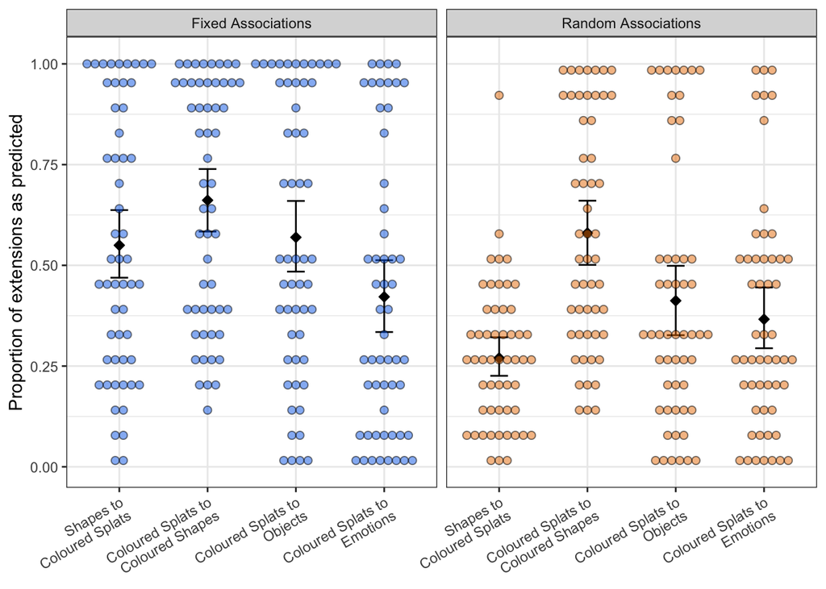

Stats - first, dummy-coded model to show an expected difference in extension from Shapes to coloured splats.

```r
director_data_2onwards <- subset(director_data, block_n >= 2)
director_data_2onwards$block_n_factor <- as.factor(director_data_2onwards$block_n)
director_data_2onwards$condition_factor <- as.factor(director_data_2onwards$condition)
contrasts(director_data_2onwards$condition_factor) <- contr.sum(2)

predicted_model_2onwards <-  glmer(predicted~block_n_factor*condition_factor + (1 + block_n_factor | pair_id),family="binomial",data=director_data_2onwards,control=glmerControl(optimizer="bobyqa",optCtrl=list(maxfun=100000)))
summary(predicted_model_2onwards)
```

```
## Generalized linear mixed model fit by maximum likelihood (Laplace
##   Approximation) [glmerMod]
##  Family: binomial  ( logit )
## Formula: predicted ~ block_n_factor * condition_factor + (1 + block_n_factor |
##     pair_id)
##    Data: director_data_2onwards
## Control: glmerControl(optimizer = "bobyqa", optCtrl = list(maxfun = 1e+05))
##
##      AIC      BIC   logLik deviance df.resid
##  13425.7  13561.1  -6694.8  13389.7    13678
##
## Scaled residuals:
##     Min      1Q  Median      3Q     Max
## -5.9780 -0.5958 -0.1608  0.4373  4.6134
##
## Random effects:
##  Groups  Name            Variance Std.Dev. Corr
##  pair_id (Intercept)     2.674    1.635
##          block_n_factor3 3.263    1.806    -0.43
##          block_n_factor4 4.464    2.113    -0.10  0.55
##          block_n_factor5 4.108    2.027    -0.29  0.23  0.26
## Number of obs: 13696, groups:  pair_id, 107
##
## Fixed effects:
##                                   Estimate Std. Error z value Pr(>|z|)
## (Intercept)                        -0.3473     0.1659  -2.093  0.03633 *
## block_n_factor3                     1.2976     0.1911   6.790 1.12e-11 ***
## block_n_factor4                     0.5869     0.2210   2.655  0.00793 **
## block_n_factor5                    -0.2272     0.2106  -1.079  0.28049
## condition_factor1                   0.8599     0.1664   5.166 2.39e-07 ***
## block_n_factor3:condition_factor1  -0.5349     0.1902  -2.812  0.00493 **
## block_n_factor4:condition_factor1  -0.2164     0.2213  -0.978  0.32823
## block_n_factor5:condition_factor1  -0.6699     0.2109  -3.176  0.00149 **
## ---
## Signif. codes:  0 '***' 0.001 '**' 0.01 '*' 0.05 '.' 0.1 ' ' 1
##
## Correlation of Fixed Effects:
##             (Intr) blc__3 blc__4 blc__5 cndt_1 b__3:_ b__4:_
## blck_n_fct3 -0.454
## blck_n_fct4 -0.160  0.522
## blck_n_fct5 -0.329  0.259  0.280
## cndtn_fctr1  0.009 -0.012 -0.012 -0.011
## blck_n_3:_1 -0.010  0.024  0.008  0.009 -0.461
## blck_n_4:_1 -0.012  0.007  0.024  0.008 -0.164  0.529
## blck_n_5:_1 -0.011  0.010  0.008  0.008 -0.332  0.264  0.283
```

Next, dummy-coded model to show no difference between conditions at block 3.

```r
director_data_3onwards <- subset(director_data, block_n >= 3)
#director_data_3onwards$blocks <- droplevels(director_data_3onwards$blocks)
director_data_3onwards$block_n_factor <- as.factor(director_data_3onwards$block_n)
director_data_3onwards$condition_factor <- as.factor(director_data_3onwards$condition)
contrasts(director_data_3onwards$condition_factor) <- contr.sum(2)

predicted_model_dummy <-  glmer(predicted~block_n_factor*condition_factor + (1 + block_n_factor | pair_id),family="binomial",data=director_data_3onwards,control=glmerControl(optimizer="bobyqa",optCtrl=list(maxfun=100000)))
summary(predicted_model_dummy)
```

```
## Generalized linear mixed model fit by maximum likelihood (Laplace
##   Approximation) [glmerMod]
##  Family: binomial  ( logit )
## Formula: predicted ~ block_n_factor * condition_factor + (1 + block_n_factor |
##     pair_id)
##    Data: director_data_3onwards
## Control: glmerControl(optimizer = "bobyqa", optCtrl = list(maxfun = 1e+05))
##
##      AIC      BIC   logLik deviance df.resid
##   9894.8   9981.6  -4935.4   9870.8    10260
##
## Scaled residuals:
##     Min      1Q  Median      3Q     Max
## -5.4344 -0.5816  0.0771  0.4412  4.4881
##
## Random effects:
##  Groups  Name            Variance Std.Dev. Corr
##  pair_id (Intercept)     3.349    1.83
##          block_n_factor4 3.572    1.89     -0.08
##          block_n_factor5 5.619    2.37     -0.47  0.34
## Number of obs: 10272, groups:  pair_id, 107
##
## Fixed effects:
##                                   Estimate Std. Error z value Pr(>|z|)
## (Intercept)                         0.9436     0.1864   5.062 4.14e-07 ***
## block_n_factor4                    -0.7156     0.2032  -3.523 0.000427 ***
## block_n_factor5                    -1.5163     0.2438  -6.219 5.00e-10 ***
## condition_factor1                   0.3142     0.1850   1.698 0.089472 .
## block_n_factor4:condition_factor1   0.3136     0.2015   1.556 0.119639
## block_n_factor5:condition_factor1  -0.1254     0.2427  -0.517 0.605446
## ---
## Signif. codes:  0 '***' 0.001 '**' 0.01 '*' 0.05 '.' 0.1 ' ' 1
##
## Correlation of Fixed Effects:
##             (Intr) blc__4 blc__5 cndt_1 b__4:_
## blck_n_fct4 -0.160
## blck_n_fct5 -0.498  0.356
## cndtn_fctr1  0.009 -0.014 -0.009
## blck_n_4:_1 -0.015  0.029  0.009 -0.147
## blck_n_5:_1 -0.009  0.009  0.005 -0.492  0.349
```

```r
director_data_3onwards$block_n_sdif <- director_data_3onwards$block_n_factor
contrasts(director_data_3onwards$block_n_sdif) <- MASS::contr.sdif(3)

predicted_model_sdif <-  glmer(predicted~block_n_sdif*condition_factor + (1 + block_n_sdif | pair_id),family="binomial",data=director_data_3onwards,control=glmerControl(optimizer="bobyqa",optCtrl=list(maxfun=100000)))
summary(predicted_model_sdif)
```

```
## Generalized linear mixed model fit by maximum likelihood (Laplace
##   Approximation) [glmerMod]
##  Family: binomial  ( logit )
## Formula: predicted ~ block_n_sdif * condition_factor + (1 + block_n_sdif |
##     pair_id)
##    Data: director_data_3onwards
## Control: glmerControl(optimizer = "bobyqa", optCtrl = list(maxfun = 1e+05))
##
##      AIC      BIC   logLik deviance df.resid
##   9894.8   9981.6  -4935.4   9870.8    10260
##
## Scaled residuals:
##     Min      1Q  Median      3Q     Max
## -5.4339 -0.5816  0.0771  0.4412  4.4881
##
## Random effects:
##  Groups  Name            Variance Std.Dev. Corr
##  pair_id (Intercept)     3.151    1.775
##          block_n_sdif2-1 3.571    1.890     0.42
##          block_n_sdif3-2 6.141    2.478    -0.25 -0.44
## Number of obs: 10272, groups:  pair_id, 107
##
## Fixed effects:
##                                   Estimate Std. Error z value Pr(>|z|)
## (Intercept)                         0.1996     0.1753   1.139 0.254871
## block_n_sdif2-1                    -0.7158     0.2031  -3.524 0.000425 ***
## block_n_sdif3-2                    -0.8005     0.2556  -3.131 0.001740 **
## condition_factor1                   0.3769     0.1752   2.152 0.031427 *
## block_n_sdif2-1:condition_factor1   0.3134     0.2015   1.556 0.119760
## block_n_sdif3-2:condition_factor1  -0.4388     0.2555  -1.718 0.085874 .
## ---
## Signif. codes:  0 '***' 0.001 '**' 0.01 '*' 0.05 '.' 0.1 ' ' 1
##
## Correlation of Fixed Effects:
##             (Intr) bl__2-1 bl__3-2 cndt_1 b__2-1:
## blck_n_s2-1  0.381
## blck_n_s3-2 -0.234 -0.454
## cndtn_fctr1 -0.002  0.000  -0.004
## blc__2-1:_1 -0.001  0.029  -0.014   0.389
## blc__3-2:_1 -0.004 -0.014   0.009  -0.235 -0.456
```

## Block-to-block distances in association matrices using KL-divergence

Including this for completeness.

For each participant in block 1 we can construct a matrix of probabilities giving the probability (frequency) with which a given target colour and signal shape co-occurred - e.g. on what proportion of trials did they send a square to communicate about a grey target? In block 1, these probabilities are determined by us - assuming they are behaving sensibly and just labelling the shape they see, this just tells us how often e.g. the target squares were grey etc. For the random associations the matrix should be more uniformly filled, since any target shape can be any colour and is therefore likely to be signalled with all shapes roughly equally frequently.

In block 2, where they label splats, we can perform the same operation and get out a similar matrix - e.g. if they were using the same set of colour-shape associations at block 2, the matrices would be similar; if they were doing something completely different we’d get quite different probabilities.

We can flatten these matrices to a single probability distribution and use KL-divergence to measure the distance between the matrices at successive blocks - we use entropy::KL.Dirichlet(block n+1,block n) on the basis that this captures the “the expected excess surprise from using block n as a model when the actual distribution is block n+1.” (https://en.wikipedia.org/wiki/Kullback–Leibler_divergence)

This isn’t quite what we want, because two random mappings will tend to be more similar to each other than two non-random mappings, so we have to control for that - we can do that using a permutation test, where we say “what would the distribution of distance scores look like if we shuffled one of these matrices?”, then convert the *actual* distance score into a z-score based on this distribution. Distance z-scores of around 0 mean that two matrices are no more similar than you would expect by chance, and negative distance z scores mean they are more similar (i.e. lower distance) than you would expect by chance. Then we can just plot those scores, comparing block 1 to block 2, block 2 to block 3, etc.

Code for this matrix distance z-scoring.

```r
#prior in the dirichlet prior for the KL-divergence calculation
kl_dirichlet_prior = 1

#a will be block n, b will be block n+1, these are reversed in the entropy::KL.Dirichlet call
distribution_distance_z <- function(a,b) {
    veridical_kl_divergence <- entropy::KL.Dirichlet(b,a,a1=kl_dirichlet_prior,a2=kl_dirichlet_prior)
    msample <- c()
    perms <- gtools::permutations(4,4)
    for (perm_i in 2:nrow(perms)) {#skip original 'permutation', which is not a permutation
      this_perm <- perms[perm_i,]
      this_divergence <- entropy::KL.Dirichlet(b[,this_perm],a,a1=kl_dirichlet_prior,a2=kl_dirichlet_prior)
      msample <- c(msample,this_divergence)
    }
    c=0
    for (i in 1:length(msample)) {
      if(msample[i]>=veridical_kl_divergence) c=c+1
    }

    return(list(mean=mean(msample),sd=sd(msample),veridical=veridical_kl_divergence,p=c/length(msample),z=(veridical_kl_divergence-mean(msample))/sd(msample)))
}
```

Code for tabulating and calculating distances per pair.

```r
tabulate_pair_kl <- function(all_data,id,print_output=FALSE) {
  this_pair_data <- subset(all_data,pair_id==id)
  this_pair_data$label <- droplevels(this_pair_data$label) #drop unused labels
  this_pair_matrices <- list()
  if (print_output) {print(paste(id,unique(this_pair_data$condition)))}

  for (b in unique(all_data$block_n)) {
    this_block_associations <- subset(this_pair_data,block_n==b)
    this_block_associations$key_feature <- droplevels(this_block_associations$key_feature) #drop unused features
    this_block_associations_xtab <- xtabs(data=this_block_associations,~key_feature+label)
  if (print_output) {
    print(paste("block",b,"colour-shape associations"))
    print(this_block_associations_xtab)}
  this_block_associations_matrix <- matrix(this_block_associations_xtab,
                                            dim(this_block_associations_xtab))
  this_pair_matrices[[b]] <- this_block_associations_matrix
  }
  #now we have all the block matrices we can compare
  block_1_2_dist <- distribution_distance_z(this_pair_matrices[[1]],this_pair_matrices[[2]])$z
  block_2_3_dist <- distribution_distance_z(this_pair_matrices[[2]],this_pair_matrices[[3]])$z
  block_3_4_dist <- distribution_distance_z(this_pair_matrices[[3]],this_pair_matrices[[4]])$z
  block_3_5_dist <- distribution_distance_z(this_pair_matrices[[3]],this_pair_matrices[[5]])$z



  this_dist_data <- data.frame("pair_id"=id,
                                 "condition"=unique(this_pair_data$condition),
                                 "blocks"=c("1-2","2-3","3-4","3-5"),
                                 "distance"=c(block_1_2_dist,block_2_3_dist,block_3_4_dist,block_3_5_dist)
  )
  this_dist_data

}
```

Finally, calculate the distances and compile into a dataframe called block_to_block_distances.

```r
block_to_block_distances <- do.call(rbind, lapply(unique(director_data$pair_id), function(p) tabulate_pair_kl(director_data,p)))
```

And plot.

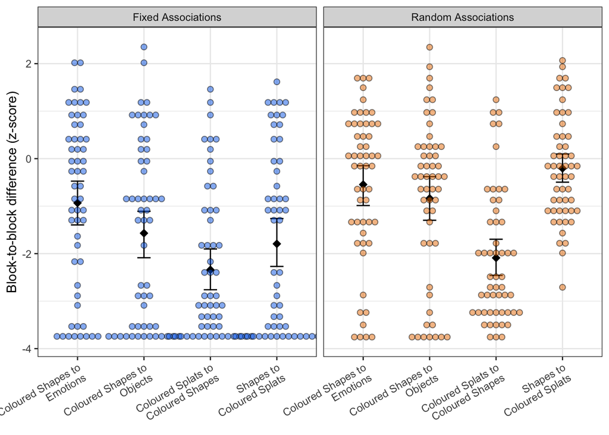

Stats - first, dummy-coded model to show no difference between conditions at block 3.

```r
block_to_block_distances_3onwards <- subset(block_to_block_distances, blocks != "1-2")
block_to_block_distances_3onwards$blocks <- factor(block_to_block_distances_3onwards$blocks)
block_to_block_distances_3onwards$blocks <- droplevels(block_to_block_distances_3onwards$blocks)


block_to_block_distances_model_dummy <-  lmerTest::lmer(distance~blocks*condition + (1 | pair_id),data=block_to_block_distances_3onwards,control=lmerControl(optimizer="bobyqa",optCtrl=list(maxfun=100000)))
summary(block_to_block_distances_model_dummy)
```

```
## Linear mixed model fit by REML. t-tests use Satterthwaite's method [
## lmerModLmerTest]
## Formula: distance ~ blocks * condition + (1 | pair_id)
##    Data: block_to_block_distances_3onwards
## Control: lmerControl(optimizer = "bobyqa", optCtrl = list(maxfun = 1e+05))
##
## REML criterion at convergence: 1193.9
##
## Scaled residuals:
##      Min       1Q   Median       3Q      Max
## -1.79343 -0.64161  0.00054  0.57690  2.31393
##
## Random effects:
##  Groups   Name        Variance Std.Dev.
##  pair_id  (Intercept) 1.238    1.112
##  Residual             1.613    1.270
## Number of obs: 321, groups:  pair_id, 107
##
## Fixed effects:
##                                        Estimate Std. Error       df t value
## (Intercept)                             -2.3398     0.2298 228.7868 -10.183
## blocks3-4                                0.7700     0.2445 210.0000   3.150
## blocks3-5                                1.4078     0.2445 210.0000   5.759
## conditionrandom_associations             0.2506     0.3265 228.7868   0.768
## blocks3-4:conditionrandom_associations   0.4829     0.3473 210.0000   1.390
## blocks3-5:conditionrandom_associations   0.1362     0.3473 210.0000   0.392
##                                        Pr(>|t|)
## (Intercept)                             < 2e-16 ***
## blocks3-4                               0.00187 **
## blocks3-5                              2.98e-08 ***
## conditionrandom_associations            0.44356
## blocks3-4:conditionrandom_associations  0.16593
## blocks3-5:conditionrandom_associations  0.69530
## ---
## Signif. codes:  0 '***' 0.001 '**' 0.01 '*' 0.05 '.' 0.1 ' ' 1
##
## Correlation of Fixed Effects:
##             (Intr) blc3-4 blc3-5 cndtn_ b3-4:_
## blocks3-4   -0.532
## blocks3-5   -0.532  0.500
## cndtnrndm_s -0.704  0.374  0.374
## blcks3-4:c_  0.374 -0.704 -0.352 -0.532
## blcks3-5:c_  0.374 -0.352 -0.704 -0.532  0.500
```

Then, successive-differences model to show change over time.

```r
block_to_block_distances_3onwards$blocks_sdif <- block_to_block_distances_3onwards$blocks
block_to_block_distances_3onwards$blocks_sdif <- factor(block_to_block_distances_3onwards$blocks_sdif)
block_to_block_distances_3onwards$condition <- factor(block_to_block_distances_3onwards$condition)

contrasts(block_to_block_distances_3onwards$blocks_sdif) <- MASS::contr.sdif(3)
contrasts(block_to_block_distances_3onwards$condition) <- contr.sum(2)

block_to_block_distances_model_sdif <-  lmerTest::lmer(distance~blocks_sdif*condition + (1 | pair_id),data=block_to_block_distances_3onwards,control=lmerControl(optimizer="bobyqa",optCtrl=list(maxfun=100000)))
summary(block_to_block_distances_model_sdif)
```

```
## Linear mixed model fit by REML. t-tests use Satterthwaite's method [
## lmerModLmerTest]
## Formula: distance ~ blocks_sdif * condition + (1 | pair_id)
##    Data: block_to_block_distances_3onwards
## Control: lmerControl(optimizer = "bobyqa", optCtrl = list(maxfun = 1e+05))
##
## REML criterion at convergence: 1198.1
##
## Scaled residuals:
##      Min       1Q   Median       3Q      Max
## -1.79343 -0.64161  0.00054  0.57690  2.31393
##
## Random effects:
##  Groups   Name        Variance Std.Dev.
##  pair_id  (Intercept) 1.238    1.112
##  Residual             1.613    1.270
## Number of obs: 321, groups:  pair_id, 107
##
## Fixed effects:
##                           Estimate Std. Error       df t value Pr(>|t|)
## (Intercept)                -1.3854     0.1288 105.0000 -10.755  < 2e-16 ***
## blocks_sdif2-1              1.0114     0.1737 210.0000   5.824 2.14e-08 ***
## blocks_sdif3-2              0.4645     0.1737 210.0000   2.675  0.00806 **
## condition1                 -0.2285     0.1288 105.0000  -1.774  0.07902 .
## blocks_sdif2-1:condition1  -0.2414     0.1737 210.0000  -1.390  0.16593
## blocks_sdif3-2:condition1   0.1733     0.1737 210.0000   0.998  0.31942
## ---
## Signif. codes:  0 '***' 0.001 '**' 0.01 '*' 0.05 '.' 0.1 ' ' 1
##
## Correlation of Fixed Effects:
##             (Intr) bl_2-1 bl_3-2 cndtn1 b_2-1:
## blcks_sd2-1  0.000
## blcks_sd3-2  0.000 -0.500
## condition1  -0.009  0.000  0.000
## blcks_2-1:1  0.000 -0.009  0.005  0.000
## blcks_3-2:1  0.000  0.005 -0.009  0.000 -0.500
```

## Non-arbitrariness of colour-shape correspondences in the arbitrary condition

One final question here is: how are the people in the random associations condition doing it in block 2 (splats, where they suddenly have to start talking about colour) - are they coming up with something arbitrary, or are there certain associations between colour and shape we were not anticipating?

Probably the simplest way to do this is just to generate a big association table and look for non-uniformity.

This actually reveals some obvious ones: star=yellow, cross=red.

```r
random_block2_associations_data <- subset(director_data,block_n==2 & condition=='random_associations')
random_block2_associations_xtab <- xtabs(data=random_block2_associations_data,~key_feature+label,drop.unused.levels=TRUE)
random_block2_associations_xtab
```

```
##            label
## key_feature circle cross diamond hexagon pentagon square star
##      grey       97    42      36      69       59     83   38
##      pink       60    68      75      62       62     58   39
##      red        69   106      34      40       40     84   51
##      yellow     67    69      36      30       53     37  132
```

```r
chisq.test(random_block2_associations_xtab)
```

```
##
##  Pearson's Chi-squared test
##
## data:  random_block2_associations_xtab
## X-squared = 208.37, df = 18, p-value < 2.2e-16
```

Do we still get an association if we remove star and cross? Yes we do, e.g. grey and red go with circle and square, pink maybe goes with diamond, etc.

```r
random_block2_associations_nostarcross_xtab <- xtabs(data=subset(random_block2_associations_data, !(label %in% c('star','cross'))),~key_feature+label,drop.unused.levels=TRUE)
random_block2_associations_nostarcross_xtab
```

```
##            label
## key_feature circle diamond hexagon pentagon square
##      grey       97      36      69       59     83
##      pink       60      75      62       62     58
##      red        69      34      40       40     84
##      yellow     67      36      30       53     37
```

```r
chisq.test(random_block2_associations_nostarcross_xtab)
```

```
##
##  Pearson's Chi-squared test
##
## data:  random_block2_associations_nostarcross_xtab
## X-squared = 54.88, df = 12, p-value = 1.902e-07
```

Are there any colours which *don’t* have a preference? Maybe only pink, which is only marginally different from uniform.

```r
for (colour in c("grey","pink","red","yellow")) {
  random_block2_associations_for_this <- xtabs(data=subset(random_block2_associations_data, key_feature==colour),~key_feature+label,drop.unused.levels=TRUE)
  print(random_block2_associations_for_this)
  print(chisq.test(random_block2_associations_for_this)$p.value)
}
```

```
##            label
## key_feature circle cross diamond hexagon pentagon square star
##        grey     97    42      36      69       59     83   38
## [1] 3.67366e-10
##            label
## key_feature circle cross diamond hexagon pentagon square star
##        pink     60    68      75      62       62     58   39
## [1] 0.05739756
##            label
## key_feature circle cross diamond hexagon pentagon square star
##         red     69   106      34      40       40     84   51
## [1] 2.062683e-13
##            label
## key_feature circle cross diamond hexagon pentagon square star
##      yellow     67    69      36      30       53     37  132
## [1] 7.501761e-24
```

Worth doing this in block 3 as well - block 2 will capture the early try-anything stages of convention formation, block 3 (talking about shapes) should show us the settled systems (which could show these preferences more clearly, or get rid of the initial panicked iconic efforts). Picture looks the same - even pink is significant at this point, although possibly due to avoiding star, circle and square.

```r
random_block3_associations_data <- subset(director_data,block_n==3 & condition=='random_associations')
random_block3_associations_xtab <- xtabs(data=random_block3_associations_data,~key_feature+label,drop.unused.levels=TRUE)
random_block3_associations_xtab
```

```
##            label
## key_feature circle cross diamond hexagon pentagon square star
##      grey       90    26      51      73       64     94   26
##      pink       55    61      89      73       74     51   21
##      red        63   105      53      38       47     83   35
##      yellow     72    70      34      22       49     47  130
```

```r
chisq.test(random_block3_associations_xtab)
```

```
##
##  Pearson's Chi-squared test
##
## data:  random_block3_associations_xtab
## X-squared = 307.79, df = 18, p-value < 2.2e-16
```

```r
for (colour in c("grey","pink","red","yellow")) {
  random_block3_associations_for_this <- xtabs(data=subset(random_block3_associations_data, key_feature==colour),~key_feature+label,drop.unused.levels=TRUE)
  print(random_block3_associations_for_this)
  print(chisq.test(random_block3_associations_for_this)$p.value)
}
```

```
##            label
## key_feature circle cross diamond hexagon pentagon square star
##        grey     90    26      51      73       64     94   26
## [1] 1.914132e-14
##            label
## key_feature circle cross diamond hexagon pentagon square star
##        pink     55    61      89      73       74     51   21
## [1] 2.098728e-08
##            label
## key_feature circle cross diamond hexagon pentagon square star
##         red     63   105      53      38       47     83   35
## [1] 6.330553e-12
##            label
## key_feature circle cross diamond hexagon pentagon square star
##      yellow     72    70      34      22       49     47  130
## [1] 1.696942e-24
```

I also wonder if we can see anything in block 5 (in the fixed condition in particular) - is there some shape-emotion correspondence messing with the colour-shape stuff? Nothing that massively jumps out, although you can see the signature of the same shape-colour correspondences we see in the random condition.

```r
fixed_block5_associations_data <- subset(director_data,block_n==5 & condition=="fixed_associations")
fixed_block5_associations_data <- xtabs(data=fixed_block5_associations_data,~key_feature+label,drop.unused.levels=TRUE)
fixed_block5_associations_data
```

```
##            label
## key_feature circle cross diamond hexagon pentagon square star
##      sad        62    73      40      98       60     57   42
##      inlove     59    71      67      41       68     61   65
##      angry      33   104      59      63       54     64   55
##      happy      78    47      51      44       32     38  142
```

```r
chisq.test(fixed_block5_associations_data)
```

```
##
##  Pearson's Chi-squared test
##
## data:  fixed_block5_associations_data
## X-squared = 181.79, df = 18, p-value < 2.2e-16
```

For reference, here’s what the block 2 associations look like in the fixed associations condition - you can see that they are influenced by the same colour-shape associations as the guys in random, so they are using the statistical associations we give them (that’s what the z-scores show) but *also* the iconic stuff like red=cross, yellow=star.

```r
fixed_block2_associations_data <- subset(director_data,block_n==2 & condition=="fixed_associations")
fixed_block2_associations_data <- xtabs(data=fixed_block2_associations_data,~key_feature+label,drop.unused.levels=TRUE)
fixed_block2_associations_data
```

```
##            label
## key_feature circle cross diamond hexagon pentagon square star
##      grey       54    55      20      65       57     80  101
##      pink       74    48      69      63       57     25   96
##      red        28    87      36      63       48     76   94
##      yellow     61    59      51      40       49     48  124
```

```r
chisq.test(fixed_block2_associations_data)
```

```
##
##  Pearson's Chi-squared test
##
## data:  fixed_block2_associations_data
## X-squared = 113.78, df = 18, p-value = 6.209e-16
```

# Citation info

Main packages cited in the paper.

```r
citation()
```

```
##
##   R Core Team (2023). _R: A Language and Environment for Statistical
##   Computing_. R Foundation for Statistical Computing, Vienna, Austria.
##   <https://www.R-project.org/>.
##
## A BibTeX entry for LaTeX users is
##
##   @Manual{,
##     title = {R: A Language and Environment for Statistical Computing},
##     author = {{R Core Team}},
##     organization = {R Foundation for Statistical Computing},
##     address = {Vienna, Austria},
##     year = {2023},
##     url = {https://www.R-project.org/},
##   }
##
## We have invested a lot of time and effort in creating R, please cite it
## when using it for data analysis. See also 'citation("pkgname")' for
## citing R packages.
```

```r
citation("ggplot2")
```

```
##
##   H. Wickham. ggplot2: Elegant Graphics for Data Analysis.
##   Springer-Verlag New York, 2016.
##
## A BibTeX entry for LaTeX users is
##
##   @Book{,
##     author = {Hadley Wickham},
##     title = {ggplot2: Elegant Graphics for Data Analysis},
##     publisher = {Springer-Verlag New York},
##     year = {2016},
##     isbn = {978-3-319-24277-4},
##     url = {https://ggplot2.tidyverse.org},
##   }
```

```r
citation("lme4")
```

```
##
##   Douglas Bates, Martin Maechler, Ben Bolker, Steve Walker (2015).
##   Fitting Linear Mixed-Effects Models Using lme4. Journal of
##   Statistical Software, 67(1), 1-48. doi:10.18637/jss.v067.i01.
##
## A BibTeX entry for LaTeX users is
##
##   @Article{,
##     title = {Fitting Linear Mixed-Effects Models Using {lme4}},
##     author = {Douglas Bates and Martin M{\"a}chler and Ben Bolker and Steve Walker},
##     journal = {Journal of Statistical Software},
##     year = {2015},
##     volume = {67},
##     number = {1},
##     pages = {1--48},
##     doi = {10.18637/jss.v067.i01},
##   }
```

```r
citation("MASS")
```

```
##
##   Venables, W. N. & Ripley, B. D. (2002) Modern Applied Statistics with
##   S. Fourth Edition. Springer, New York. ISBN 0-387-95457-0
##
## A BibTeX entry for LaTeX users is
##
##   @Book{,
##     title = {Modern Applied Statistics with S},
##     author = {W. N. Venables and B. D. Ripley},
##     publisher = {Springer},
##     edition = {Fourth},
##     address = {New York},
##     year = {2002},
##     note = {ISBN 0-387-95457-0},
##     url = {https://www.stats.ox.ac.uk/pub/MASS4/},
##   }
```

For the KL-divergence analysis we also use entropy and gtools (for permutations).

```r
citation("entropy")
```

```
##
##   Hausser J, Strimmer K (2021). _entropy: Estimation of Entropy, Mutual
##   Information and Related Quantities_. R package version 1.3.1,
##   <https://CRAN.R-project.org/package=entropy>.
##
## A BibTeX entry for LaTeX users is
##
##   @Manual{,
##     title = {entropy: Estimation of Entropy, Mutual Information and Related Quantities},
##     author = {Jean Hausser and Korbinian Strimmer},
##     year = {2021},
##     note = {R package version 1.3.1},
##     url = {https://CRAN.R-project.org/package=entropy},
##   }
##
## ATTENTION: This citation information has been auto-generated from the
## package DESCRIPTION file and may need manual editing, see
## 'help("citation")'.
```

```r
citation("gtools")
```

```
##
##   Warnes G, Bolker B, Lumley T, Magnusson A, Venables B, Ryodan G,
##   Moeller S (2023). _gtools: Various R Programming Tools_. R package
##   version 3.9.5, <https://CRAN.R-project.org/package=gtools>.
##
## A BibTeX entry for LaTeX users is
##
##   @Manual{,
##     title = {gtools: Various R Programming Tools},
##     author = {Gregory R. Warnes and Ben Bolker and Thomas Lumley and Arni Magnusson and Bill Venables and Genei Ryodan and Steffen Moeller},
##     year = {2023},
##     note = {R package version 3.9.5},
##     url = {https://CRAN.R-project.org/package=gtools},
##   }
```